# Simultaneous Detection of Compromised Items and Examinees with Item Preknowledge using Response Time Information

## Simulated Data Example

### Data Generation

I will first simulate a dataset to test the performance the model. The followings are some important variables to consider in this simulation:

$$\begin{pmatrix}
\tau_t \\ \tau_c
\end{pmatrix}
=
N(\mu_{\mathcal{P}},\Sigma_{\mathcal{P}} )$$

with $\mu_{\mathcal{P}} = (0,0.4)$ and

$$\Sigma_{\mathcal{P}} =
\begin{pmatrix}
0.0100 \ \ 0.0105 \\
0.0105 \ \ 0.0225
\end{pmatrix}.$$

The specifications about $\tau_t$ and $\tau_c$ correspond to a correlation of 0.7 between true latent speed and cheating latent speed, an about %35 reduction in response time on average when an examinees responds to a compromised item. Below are the code to simulate response time data with these specifications.

```
require(MASS)

set.seed(06202021)

N = 200    # number of examinees
n = 30     # number of items

# Time intensity parameters

  beta  <- rnorm(n,4,.5)

# Time discrimination parameters

  alpha <- rnorm(n,2,0.5)

# Tau_t and tau_c

  tau <- mvrnorm(N,
                 mu = c(0,0.4),
                 Sigma = matrix(c(0.01,0.0105,0.0105,0.0225),2,2))

  tau_t <- tau[,1]
  tau_c <- tau[,2]

# Randomly select (approximately) 20% of examinees as having item prekowledge

  H <- rbinom(N,1,.2)

# Randomly select (approximately) 50% of items as compromised

  C <- rbinom(n,1,.5)

# Generate observed response times according to the model

  rt <- matrix(nrow=N,ncol=n)

  for(i in 1:N){
    for(j in 1:n){

      p_t <- beta[j] - tau_t[i]
      p_c <- beta[j] - tau_c[i]

      if(H[i] == 1 & C[j] == 1){
        rt[i,j] = exp(rnorm(1,p_c,1/alpha[j]))
      } else {
        rt[i,j] = exp(rnorm(1,p_t,1/alpha[j]))
      }

    }
  }

  # Convert it to data frame and add group membership and a unique ID

    rt       <- as.data.frame(rt)
    rt$group <- H
    rt$id    <- 1:nrow(rt)

  # Check the data

  head(rt)
```

```
      V1     V2     V3     V4    V5    V6     V7     V8     V9    V10
1 128.22  47.50  65.83  82.58 17.13 35.31  24.21 184.04  29.48 14.449
2 353.25 126.99 191.42 110.42 53.50 76.33  33.65  95.92 163.65 13.782
3  72.86  47.72 116.38 157.30 86.60 28.66 123.08  52.51  67.22 22.403
4  91.98  51.01 137.09 167.42 30.12 95.76  40.70 219.40  33.01 75.115
5  25.87  78.50  76.75 175.06 68.95 33.80  30.32  59.24  72.79  4.150
6 256.00 107.92  73.04  71.10 82.48 38.20  68.92  34.24  41.14  2.515
    V11   V12   V13    V14   V15    V16   V17   V18   V19   V20
1 37.07 29.56 51.73 106.69 39.70  49.75 62.55 44.58 58.64 107.4
2 38.90 13.66 79.53  91.17 49.38  67.88 65.12 70.00 47.08  17.3
3 40.04 18.19 61.68  72.10 44.50 223.67 43.79 49.39 44.58 235.2
4 50.57 43.59 49.65  96.93 86.55  55.34 41.29 32.95 42.70 329.3
5 70.53 24.22 21.34  63.83 43.70 157.27 82.45 35.00 75.03 147.9
6 64.42 20.53 41.58  79.14 45.88  45.94 50.70 21.43 32.15 266.0
     V21    V22   V23     V24    V25   V26   V27    V28   V29   V30
1  79.04 100.73 103.3   6.736 104.52 32.80 87.32  61.66 61.07 43.29
2 187.34 196.59 176.8  86.660  47.96 40.85 83.93  78.75 59.47 12.33
3  85.58  48.59 136.2  79.418 101.56 40.03 65.18  24.61 67.75 41.38
4  62.51  73.77 118.6 225.904 158.70 29.83 42.67  48.28 56.17 48.89
5 144.93  52.72 180.7 997.649  66.67 32.88 42.35 121.88 61.07 20.01
6  59.06  54.31  68.0 190.259  53.75 20.64 40.75  31.81 75.62 16.28
  group id
1     0  1
2     0  2
3     0  3
4     0  4
5     0  5
6     1  6
```

```
  # Reshape it to long format (for plotting purposes)

  rt.long <- reshape(data        = rt,
                     idvar       = 'id',
                     varying     = list(colnames(rt)[1:n]),
                     timevar     = "Item",
                     times       = 1:n,
                     v.names      = "RT",
                     direction   = "long")

  # Add item status

    rt.long$compromised <- NA

    for(j in 1:n){

      rt.long[rt.long$Item==j,]$compromised = C[j]

    }

  head(rt.long)
```

```
    group id Item     RT compromised
1.1     0  1    1 128.22           0
2.1     0  2    1 353.25           0
3.1     0  3    1  72.86           0
4.1     0  4    1  91.98           0
5.1     0  5    1  25.87           0
6.1     1  6    1 256.00           0
```

### Data Check

Below boxplots provide a snapshot of distributions for the generated response times for hypothetetical examinees with and without item preknowledge for compromised and uncompromised items. Not surprisingly, average log response time is about same for two groups of examinees for uncompromised items while examinees with item preknowledge respond slightly faster to compromised items.

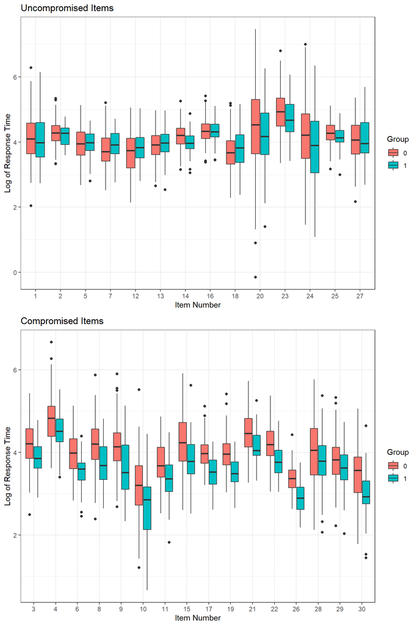

```
require(ggplot2)
require(gridExtra)

p1 <- ggplot(rt.long[rt.long$compromised==0,],
             aes(x=factor(Item), y=log(RT),fill=factor(group))) +
       geom_boxplot()+
       theme_bw() +
       xlab('Item Number')+
       ylab('Log of Response Time')+
       guides(fill=guide_legend(title="Group"))+
       ggtitle('Uncompromised Items')



p2 <- ggplot(rt.long[rt.long$compromised==1,],
             aes(x=factor(Item), y=log(RT),fill=factor(group))) +
       geom_boxplot()+
       theme_bw() +
       xlab('Item Number')+
       ylab('Log of Response Time')+
       guides(fill=guide_legend(title="Group"))+
       ggtitle('Compromised Items')

grid.arrange(p1,p2)
```

### Fitting the model

We first prepare a list for the input data.

```
data_rt <- list(
  I               = 200,
  J               = 30,
  RT              = log(rt[,1:30])
)
```

I will use the `cmdstanr` package to fit the model using the Stan model syntax developed before. There are four chains. There are 100 warm-up iterations followed by 500 sampling iterations for each chain.

```
require(here)
require(cmdstanr)
require(rstan)

mod <- cmdstan_model(here('_posts/dglnrt2/dglnrt.stan'))

  fit <- mod$sample(
    data            = data_rt,
    seed            = 1234,
    chains          = 4,
    parallel_chains = 4,
    iter_warmup     = 100,
    iter_sampling   = 500,
    refresh         = 10,
    adapt_delta     = 0.99)

  fit$cmdstan_summary()

  stanfit <- rstan::read_stan_csv(fit$output_files())
```

This model took about 3 hours to run on my computer. There are so many parameters in the model. I will only focus on two for the sake of keeping this post short. These parameters are the probability of being compromised for each item and probability of each examinee having item preknowledge.

### Probability of items being compromised

As you can see the numbers below, the model predicted probability estimates perfectly separated two groups of items (disclosed and undisclosed). $\hat{R}$ values ranged from 0.999 to 1.002, suggesting good convergence. The probability estimates ranged from 0.12 to 0.54 with an average of 0.27 for the simulated uncompromised items, while they ranged from 0.54 to 0.86 with a mean of 0.72 for the simulated compromised items. The AUC estimate was one, indicating that the probability estimates coming out of the model did a perfect job of separating the items in these two groups. The perfect separation of two groups of items can also be seen in the density plots below. For instance, if one uses a cut-off value of 0.5 to detect whether or not an item is compromised, this model would accurately detect all compromised items while detecting only one uncompromised item as false-positive.

```
require(rstan)
require(psych)
require(mltools)

pC <- as.data.frame(summary(stanfit, pars = c("pC"), probs = c(0.025, 0.975))$summary)
pC$trueC <- C

pC
```

```
         mean  se_mean     sd     2.5%  97.5% n_eff   Rhat trueC
pC[1]  0.3563 0.005331 0.2633 0.012007 0.9306  2441 1.0003     0
pC[2]  0.1932 0.004339 0.1858 0.003961 0.7395  1834 0.9986     0
pC[3]  0.6770 0.004731 0.2252 0.172258 0.9866  2266 0.9999     1
pC[4]  0.6837 0.004058 0.2315 0.137451 0.9871  3254 0.9988     1
pC[5]  0.2595 0.004195 0.2037 0.010536 0.7682  2357 0.9989     0
pC[6]  0.8133 0.003423 0.1654 0.384424 0.9958  2334 1.0002     1
pC[7]  0.1522 0.002641 0.1467 0.003595 0.5455  3084 0.9993     0
pC[8]  0.7864 0.004274 0.1963 0.260266 0.9928  2110 0.9999     1
pC[9]  0.6778 0.004485 0.2187 0.170020 0.9824  2378 0.9993     1
pC[10] 0.7160 0.004703 0.2346 0.152268 0.9923  2488 0.9991     1
pC[11] 0.7550 0.003958 0.1945 0.275246 0.9927  2414 0.9990     1
pC[12] 0.1787 0.002780 0.1603 0.005530 0.5975  3324 0.9988     0
pC[13] 0.1358 0.002122 0.1230 0.005882 0.4551  3362 0.9988     0
pC[14] 0.1870 0.003053 0.1627 0.005551 0.6030  2839 0.9985     0
pC[15] 0.6533 0.004923 0.2526 0.104433 0.9868  2632 0.9990     1
pC[16] 0.1161 0.001755 0.1103 0.002838 0.4098  3949 0.9986     0
pC[17] 0.8541 0.002521 0.1309 0.508814 0.9948  2698 0.9989     1
pC[18] 0.2686 0.003645 0.2054 0.012220 0.7619  3174 0.9996     0
pC[19] 0.7572 0.003563 0.1796 0.342210 0.9889  2542 1.0001     1
pC[20] 0.4645 0.005634 0.2798 0.023069 0.9560  2466 0.9997     0
pC[21] 0.5698 0.006223 0.2741 0.048376 0.9808  1940 1.0006     1
pC[22] 0.8236 0.002805 0.1558 0.418939 0.9957  3086 0.9998     1
pC[23] 0.3749 0.005344 0.2551 0.020048 0.9501  2279 0.9991     0
pC[24] 0.5375 0.005135 0.2758 0.036191 0.9696  2885 0.9998     0
pC[25] 0.2763 0.003512 0.1531 0.035231 0.6321  1900 0.9996     0
pC[26] 0.8555 0.002401 0.1230 0.540512 0.9951  2624 0.9994     1
pC[27] 0.2609 0.004345 0.2118 0.006762 0.7792  2376 1.0005     0
pC[28] 0.6474 0.005694 0.2528 0.075939 0.9825  1971 1.0024     1
pC[29] 0.5402 0.006249 0.2645 0.058637 0.9793  1792 0.9996     1
pC[30] 0.7360 0.003684 0.2070 0.242707 0.9902  3156 1.0006     1
```

```
describeBy(pC[,1],group=C)
```

```
 Descriptive statistics by group
group: 0
   vars  n mean   sd median trimmed  mad  min  max range skew
X1    1 14 0.27 0.13   0.26    0.26 0.13 0.12 0.54  0.42 0.71
   kurtosis   se
X1    -0.68 0.03
----------------------------------------------------
group: 1
   vars  n mean   sd median trimmed mad  min  max range  skew
X1    1 16 0.72 0.09   0.73    0.73 0.1 0.54 0.86  0.32 -0.26
   kurtosis   se
X1       -1 0.02
```

```
auc_roc(preds = pC[,1],
        actuals = C)
```

```
[1] 1
```

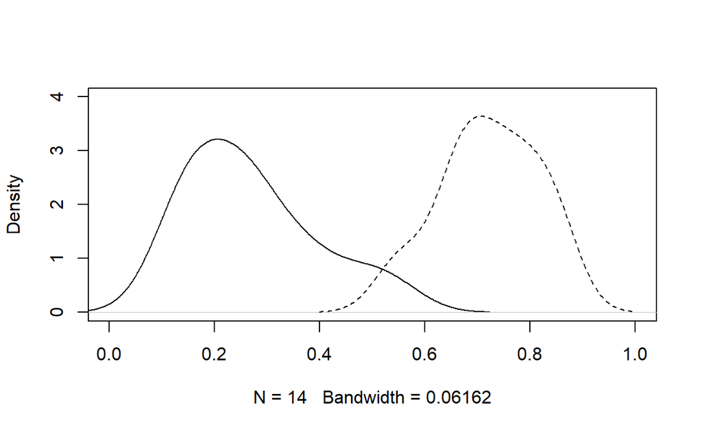

```
plot(density(pC[C==0,1]),xlim=c(0,1),main="",ylim = c(0,4))
points(density(pC[C==1,1]),lty=2,type='l')
```

```
table(pC$trueC,pC$mean>.5)
```

```
    FALSE TRUE
  0    13    1
  1     0   16
```

### Probability of examinees having item preknowledge

The probability estimates of examinees having item preknowledge were not as perfect as the probability estimates of items being compromised. However, it still provided some promising results. $\hat{R}$ values ranged from 0.998 to 1.003, indicating good convergence.

```
pH       <- as.data.frame(summary(stanfit, pars = c("pH"), probs = c(0.025, 0.975))$summary)
pH$trueH <- H

pH
```

```
          mean  se_mean     sd    2.5%  97.5% n_eff   Rhat trueH
pH[1]   0.4324 0.005780 0.2824 0.01983 0.9593  2387 0.9996     0
pH[2]   0.4136 0.005989 0.2787 0.01559 0.9511  2166 0.9999     0
pH[3]   0.5109 0.005373 0.2874 0.02531 0.9800  2861 0.9994     0
pH[4]   0.4206 0.005508 0.2821 0.01639 0.9614  2623 0.9988     0
pH[5]   0.4268 0.005394 0.2904 0.01805 0.9623  2899 0.9999     0
pH[6]   0.5801 0.006208 0.2842 0.03852 0.9822  2096 1.0004     1
pH[7]   0.6987 0.004690 0.2344 0.12410 0.9891  2499 1.0000     1
pH[8]   0.4221 0.005439 0.2864 0.01218 0.9622  2772 0.9990     0
pH[9]   0.4609 0.005260 0.2880 0.02414 0.9687  2997 0.9982     0
pH[10]  0.4394 0.005621 0.2843 0.01791 0.9597  2558 0.9995     0
pH[11]  0.6211 0.005172 0.2663 0.08076 0.9899  2650 1.0005     1
pH[12]  0.3967 0.005952 0.2793 0.01306 0.9511  2202 1.0008     0
pH[13]  0.4979 0.004903 0.2857 0.02238 0.9684  3396 0.9991     0
pH[14]  0.4384 0.005724 0.2860 0.01822 0.9726  2496 1.0003     0
pH[15]  0.6246 0.004260 0.2510 0.10713 0.9795  3471 0.9983     1
pH[16]  0.4910 0.005116 0.2852 0.03087 0.9741  3109 0.9996     0
pH[17]  0.4716 0.005892 0.3009 0.01573 0.9804  2608 0.9987     0
pH[18]  0.5877 0.005723 0.2834 0.03934 0.9857  2453 1.0004     1
pH[19]  0.6095 0.004547 0.2557 0.08294 0.9814  3163 0.9999     1
pH[20]  0.4515 0.005513 0.2850 0.01788 0.9746  2672 0.9993     0
pH[21]  0.4060 0.005564 0.2795 0.02181 0.9510  2522 0.9983     0
pH[22]  0.4139 0.005748 0.2818 0.01848 0.9596  2404 1.0014     0
pH[23]  0.6297 0.004776 0.2633 0.07521 0.9907  3040 0.9999     0
pH[24]  0.4744 0.005470 0.2886 0.02303 0.9710  2783 0.9997     0
pH[25]  0.4834 0.005000 0.2819 0.02755 0.9699  3179 0.9985     0
pH[26]  0.4323 0.005653 0.2830 0.01623 0.9650  2505 0.9984     0
pH[27]  0.4730 0.005524 0.2868 0.02018 0.9697  2696 0.9995     0
pH[28]  0.4979 0.004819 0.2647 0.03945 0.9614  3018 0.9999     0
pH[29]  0.5412 0.005606 0.2734 0.04473 0.9761  2379 0.9994     1
pH[30]  0.4560 0.005916 0.2895 0.01943 0.9708  2394 0.9997     0
pH[31]  0.5826 0.005193 0.2714 0.04864 0.9877  2732 0.9991     0
pH[32]  0.4468 0.005107 0.2803 0.01915 0.9721  3012 0.9989     0
pH[33]  0.4665 0.005612 0.2961 0.01629 0.9748  2785 1.0001     0
pH[34]  0.4796 0.005778 0.2873 0.02307 0.9687  2473 0.9989     0
pH[35]  0.5197 0.005582 0.2828 0.03814 0.9758  2567 0.9988     0
pH[36]  0.5581 0.005635 0.2750 0.03497 0.9746  2381 0.9989     1
pH[37]  0.4389 0.005213 0.2841 0.02194 0.9539  2971 1.0003     0
pH[38]  0.4187 0.005596 0.2746 0.02036 0.9573  2408 1.0004     0
pH[39]  0.5116 0.005338 0.2863 0.03419 0.9801  2876 0.9989     0
....
```

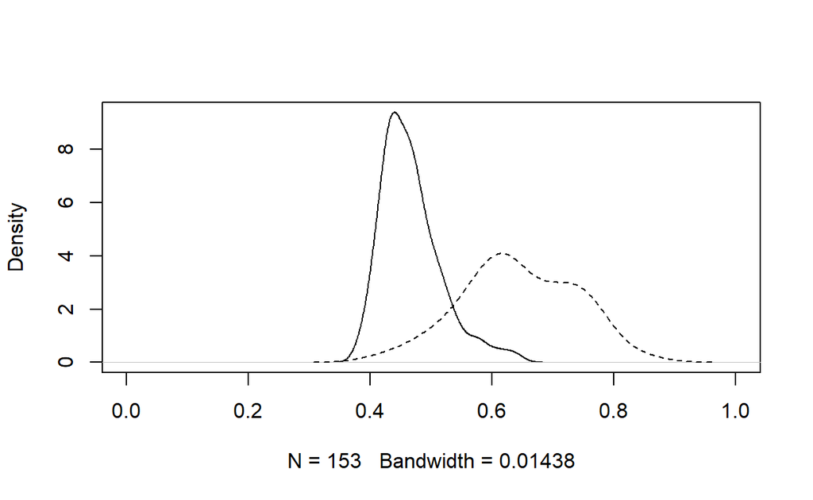

```
plot(density(pH[H==0,1]),xlim=c(0,1),main="")
points(density(pH[H==1,1]),type='l',lty=2)
```

```
describeBy(pH[,1],group=H)
```

```
 Descriptive statistics by group
group: 0
   vars   n mean   sd median trimmed  mad  min  max range skew
X1    1 153 0.47 0.05   0.46    0.46 0.04 0.39 0.64  0.25 1.09
   kurtosis se
X1      1.3  0
----------------------------------------------------
group: 1
   vars  n mean   sd median trimmed mad  min  max range  skew
X1    1 47 0.64 0.09   0.63    0.65 0.1 0.42 0.84  0.42 -0.11
   kurtosis   se
X1    -0.54 0.01
```

```
auc_roc(preds = pH[,1],
        actuals =H)
```

```
[1] 0.9492
```

For instance, if one uses a cut-off value of 0.6 to detect whether or not an examinee has item preknowledge, we would get the following confusion matrix, yielding a false-positive rate of 0.026, true-positive rate of 0.68, and precision of 0.89.

```
table(pH$trueH,pH$mean>.6)
```

```
    FALSE TRUE
  0   149    4
  1    15   32
```

## Real Data Example

In this dataset, there are 93 examinees and 25 items. Below is the first three rows and 5 columns (not allowed to publicize this dataset). The first two columns are variables for a unique identification number and a group membership. The last 25 items include the observed response time for 25 items in the test.

```
  ID COND  Q1RT  Q2RT   Q3RT
1  1    2 35.59 15.05  68.66
2  2    1 70.30 67.82 126.90
3  3    3 50.45 34.71 299.22
```

```
[1] 93 27
```

```
 1  2  3
33 30 30
```

One group (Group 1) was a control group, and they responded to all 25 items without any preknowledge. The second and third groups were experimental groups. Group 2 was allowed to study 12 items (even-numbered items) without the correct key, while Group 3 was allowed to study the same 12 items with the correct key before taking the test. The plots below show the distribution of log response time within each group for odd-numbered items and even-numbered items. While there is not much difference among the groups for the undisclosed odd-numbered items, the experimental effect reveals itself with shorter response times in disclosed even-numbered items for the examinees in Group 2 and 3. So, in theory, the model should successfully separate these three groups of examinees by assigning a higher probability of item preknowledge for examinees in Group 2 and Group 3. Also, the model should successfully separate two groups of items by assigning a higher probability of being compromised for the even-numbered items.

### Data Check

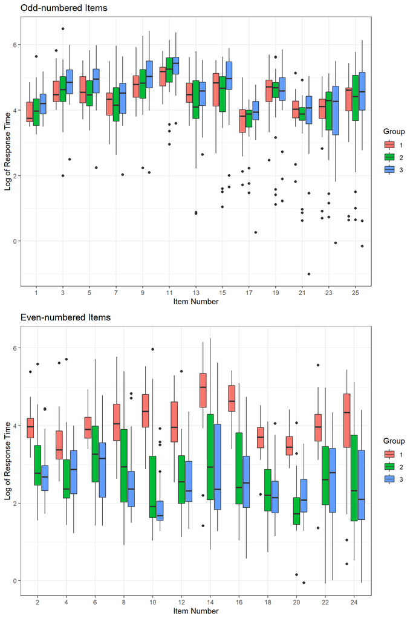

### Model Fitting

We first prepare a list for the input data.

```
data_rt <- list(
  I               = 93,
  J               = 25,
  RT              = log(d.sub[,3:27])
)
```

I will use the `cmdstanr` package to fit the model using the Stan model syntax developed before. There are four chains. There are 100 warm-up iterations followed by 500 sampling iterations for each chain.

```
require(cmdstanr)

mod <- cmdstan_model(here('_posts/dglnrt2/dglnrt.stan'))

  fit <- mod$sample(
    data            = data_rt,
    seed            = 1234,
    chains          = 4,
    parallel_chains = 4,
    iter_warmup     = 100,
    iter_sampling   = 500,
    refresh         = 10,
    adapt_delta     = 0.99)

  fit$cmdstan_summary()

  stanfit <- rstan::read_stan_csv(fit$output_files())
```

It took about 35 minutes to run on my computer.

### Probability of items being compromised

The probability estimates ranged from 0.02 t0 0.39 with an average of 0.14 for the undisclosed items, while they ranged from 0.81 to 0.98 with a mean of 0.92 for the disclosed items. The AUC estimate was one indicating a perfect separation of the disclosed and undisclosed items. The perfect separation of two groups of items can also be seen in the density plots below. For instance, if one uses a cut-off value of 0.5 to detect whether or not an item is compromised, this model would perfectly recover the disclosed items in the experimental setting.

```
pC       <- as.data.frame(summary(stanfit, pars = c("pC"), probs = c(0.025, 0.975))$summary)
pC$trueC <- c(rep(c(0,1),12),0)
pC
```

```
          mean   se_mean      sd      2.5%  97.5% n_eff   Rhat trueC
pC[1]  0.02279 0.0003900 0.02248 0.0004506 0.0837  3324 0.9989     0
pC[2]  0.89192 0.0013721 0.06822 0.7318409 0.9901  2472 0.9998     1
pC[3]  0.06429 0.0007507 0.03883 0.0105791 0.1536  2676 0.9986     0
pC[4]  0.81685 0.0021437 0.10149 0.6056597 0.9846  2241 0.9993     1
pC[5]  0.04235 0.0005289 0.03252 0.0022409 0.1231  3781 0.9993     0
pC[6]  0.81485 0.0019671 0.10300 0.5808236 0.9804  2742 1.0001     1
pC[7]  0.04267 0.0006814 0.03823 0.0011927 0.1470  3147 0.9986     0
pC[8]  0.90350 0.0012449 0.06826 0.7435097 0.9945  3007 0.9992     1
pC[9]  0.07053 0.0008697 0.04076 0.0137320 0.1691  2196 0.9988     0
pC[10] 0.96293 0.0005276 0.03304 0.8749595 0.9990  3922 0.9986     1
pC[11] 0.06193 0.0006584 0.03901 0.0066121 0.1538  3511 0.9991     0
pC[12] 0.96692 0.0005443 0.03160 0.8823371 0.9991  3370 0.9987     1
pC[13] 0.12841 0.0013142 0.05894 0.0366359 0.2590  2012 1.0007     0
pC[14] 0.90235 0.0012686 0.06766 0.7481475 0.9943  2845 0.9982     1
pC[15] 0.17636 0.0015006 0.06346 0.0702638 0.3134  1788 0.9993     0
pC[16] 0.95090 0.0007565 0.04326 0.8438114 0.9982  3270 0.9993     1
pC[17] 0.14062 0.0012718 0.04873 0.0619892 0.2493  1468 1.0002     0
pC[18] 0.97221 0.0004352 0.02676 0.9038320 0.9993  3782 0.9989     1
pC[19] 0.17644 0.0013468 0.05956 0.0753981 0.3037  1955 1.0007     0
pC[20] 0.97648 0.0004188 0.02381 0.9119659 0.9995  3234 0.9990     1
pC[21] 0.18806 0.0014627 0.06141 0.0847824 0.3196  1763 0.9989     0
pC[22] 0.94778 0.0007269 0.04725 0.8258265 0.9985  4225 0.9987     1
pC[23] 0.38546 0.0018617 0.08426 0.2317135 0.5528  2048 0.9987     0
pC[24] 0.95307 0.0007975 0.04418 0.8357623 0.9990  3068 0.9983     1
pC[25] 0.30796 0.0018838 0.08074 0.1618400 0.4814  1837 1.0008     0
```

```
describeBy(pC$mean,group=pC$trueC)
```

```
 Descriptive statistics by group
group: 0
   vars  n mean   sd median trimmed mad  min  max range skew kurtosis
X1    1 13 0.14 0.11   0.13    0.13 0.1 0.02 0.39  0.36 0.91    -0.31
     se
X1 0.03
----------------------------------------------------
group: 1
   vars  n mean   sd median trimmed  mad  min  max range  skew
X1    1 12 0.92 0.06   0.95    0.93 0.04 0.81 0.98  0.16 -0.84
   kurtosis   se
X1    -0.83 0.02
```

```
auc_roc(preds = pC$mean,
        actuals = pC$trueC)
```

```
[1] 1
```

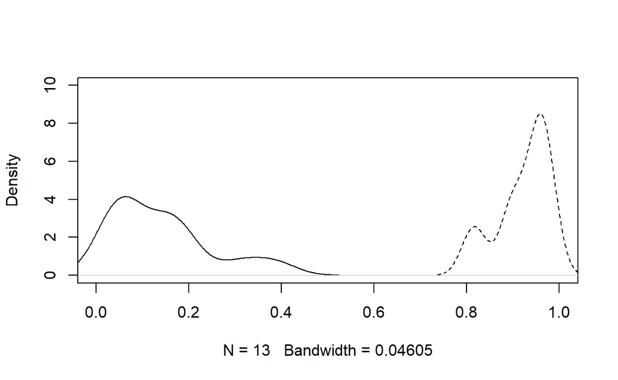

```
plot(density(pC[pC$trueC==0,1]),xlim=c(0,1),main="",ylim = c(0,10))
points(density(pC[pC$trueC==1,1]),lty=2,type='l')
```

```
table(pC$trueC,pC$mean>.5)
```

```
    FALSE TRUE
  0    13    0
  1     0   12
```

### Probability of examinees having item preknowledge

```
pH       <- as.data.frame(summary(stanfit, pars = c("pH"), probs = c(0.025, 0.975))$summary)
pH$trueH <- ifelse(d.sub$COND==1,0,1)
pH
```

```
         mean   se_mean      sd     2.5%  97.5%  n_eff   Rhat trueH
pH[1]  0.3739 0.0033378 0.16536 0.122342 0.7767 2454.5 1.0000     1
pH[2]  0.4207 0.0070813 0.28521 0.011273 0.9436 1622.3 1.0003     0
pH[3]  0.7659 0.0025472 0.16281 0.403952 0.9892 4085.5 0.9992     1
pH[4]  0.8687 0.0022007 0.12117 0.543230 0.9974 3031.5 0.9990     1
pH[5]  0.5147 0.0029313 0.14882 0.238189 0.8025 2577.7 1.0005     1
pH[6]  0.3002 0.0080551 0.26823 0.006125 0.9330 1108.8 0.9994     0
pH[7]  0.9108 0.0013505 0.07872 0.710695 0.9979 3397.7 1.0007     1
pH[8]  0.3093 0.0074335 0.27576 0.006109 0.9203 1376.2 1.0002     0
pH[9]  0.7587 0.0025103 0.15675 0.407047 0.9869 3899.3 0.9987     1
pH[10] 0.4637 0.0083978 0.29984 0.022981 0.9781 1274.8 1.0015     0
pH[11] 0.9288 0.0010362 0.06615 0.756134 0.9975 4075.2 0.9990     1
pH[12] 0.3201 0.0071752 0.26811 0.007590 0.9103 1396.2 0.9997     0
pH[13] 0.9138 0.0012575 0.07982 0.706961 0.9970 4028.7 0.9998     1
pH[14] 0.7041 0.0025965 0.17764 0.337529 0.9813 4680.7 0.9988     1
pH[15] 0.8360 0.0021308 0.13367 0.484906 0.9942 3935.3 0.9986     1
pH[16] 0.2553 0.0021182 0.10702 0.082439 0.4883 2552.8 0.9985     0
pH[17] 0.3125 0.0080216 0.27730 0.006544 0.9434 1195.0 1.0023     0
pH[18] 0.7939 0.0020365 0.12933 0.503429 0.9765 4033.2 0.9984     1
pH[19] 0.8375 0.0017937 0.11516 0.564244 0.9921 4121.6 0.9995     1
pH[20] 0.3023 0.0025411 0.11439 0.102210 0.5504 2026.5 1.0002     0
pH[21] 0.8513 0.0017211 0.11240 0.579003 0.9932 4264.8 0.9984     1
pH[22] 0.8032 0.0034052 0.17463 0.353354 0.9933 2630.1 0.9994     1
pH[23] 0.4993 0.0028453 0.17052 0.182437 0.8394 3591.6 0.9983     1
pH[24] 0.3269 0.0089522 0.29332 0.006415 0.9582 1073.5 1.0012     0
pH[25] 0.5905 0.0029961 0.17361 0.261305 0.9003 3357.6 0.9986     1
pH[26] 0.6889 0.0023612 0.14412 0.387882 0.9471 3725.7 1.0004     1
pH[27] 0.3241 0.0072829 0.27493 0.006545 0.9241 1425.1 0.9999     0
pH[28] 0.9079 0.0013019 0.08094 0.699641 0.9966 3865.1 0.9994     1
pH[29] 0.2670 0.0091847 0.27534 0.004448 0.9344  898.7 1.0027     0
pH[30] 0.3494 0.0087796 0.29115 0.008960 0.9549 1099.8 1.0059     0
pH[31] 0.7718 0.0026901 0.16225 0.402562 0.9865 3637.5 0.9987     1
pH[32] 0.9460 0.0009635 0.05386 0.798829 0.9988 3124.2 0.9999     1
pH[33] 0.8285 0.0023823 0.13438 0.498653 0.9934 3181.8 0.9995     1
pH[34] 0.8664 0.0019269 0.11983 0.559261 0.9957 3866.9 0.9994     1
pH[35] 0.2598 0.0078278 0.23986 0.016484 0.8936  939.0 1.0025     0
pH[36] 0.6521 0.0026381 0.11940 0.411404 0.8725 2048.6 0.9997     1
pH[37] 0.3112 0.0088663 0.27708 0.006535 0.9422  976.6 1.0007     0
pH[38] 0.6841 0.0026520 0.16076 0.355268 0.9535 3674.6 0.9992     1
pH[39] 0.7209 0.0024327 0.14626 0.405216 0.9577 3614.7 0.9989     1
....
```

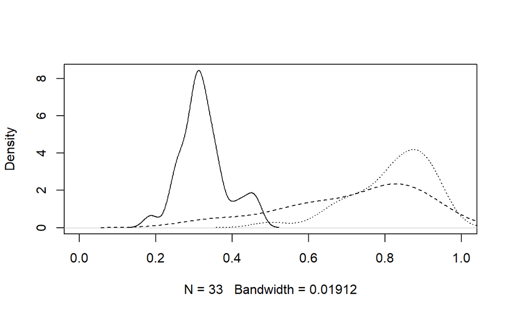

```
plot(density(pH[which(d.sub$COND==1),1]),xlim=c(0,1),main="")
points(density(pH[which(d.sub$COND==2),1]),type='l',lty=2)
points(density(pH[which(d.sub$COND==3),1]),type='l',lty=3)
```

```
describeBy(pH$mean,group=d.sub$COND)
```

```
 Descriptive statistics by group
group: 1
   vars  n mean   sd median trimmed  mad  min  max range skew
X1    1 33 0.32 0.06   0.31    0.32 0.05 0.19 0.46  0.28 0.46
   kurtosis   se
X1     0.07 0.01
----------------------------------------------------
group: 2
   vars  n mean   sd median trimmed  mad min  max range  skew
X1    1 30 0.72 0.18   0.78    0.73 0.17 0.3 0.94  0.64 -0.72
   kurtosis   se
X1    -0.52 0.03
----------------------------------------------------
group: 3
   vars  n mean  sd median trimmed  mad min  max range skew kurtosis
X1    1 30 0.82 0.1   0.84    0.83 0.11 0.5 0.95  0.45 -1.1     0.79
     se
X1 0.02
```

```
auc_roc(preds = pH$mean,
        actuals = pH$trueH)
```

```
[1] 0.9828
```

For instance, if one uses a cut-off value of 0.5 to detect whether or not an examinee has item preknowledge, we would get the following confusion matrix, yielding a false-positive rate of 0, true-positive rate of 0.92, and precision of 1.

```
table(pH$trueH,pH$mean>.5)
```

```
    FALSE TRUE
  0    33    0
  1     5   55
```

## Some Considerations

I think we have a decent model that may potentially work in practice. The most important thing about this model is that it does not assume that the compromised items are known. The model returns a probability of an item being compromised and a probability of an examinee having item preknowledge. Below are some considerations about this model as I work on improving it:

- The model can easily be generalized to incorporate actual item response data (0: correct, 1:incorrect), as a modified version of van der Linden’s Hierarchical IRT model. The model performance would potentially be better by incorporating information from both item responses and response times (it is almost done, will be posted soon!).
- The model is flexible enough to incorporate partial information. Suppose that you know certain items were compromised (e.g., through web monitoring) and certain examinees had item preknowledge (e.g., confession). This information can be provided to the model by fixing the relevant values to 1 in the **transformed parameters** block.
- The promising results in this post using the experimental data from Toton and Maynes (2019) are probably overestimating how this model would perform in a real setting. We know that the effect size of item preknowledge on response times in this dataset is massive, yielding 70%-80% reductions in response time. Similarly, the item preknowledge effect in the simulated data example yields on average about 35% reduction in response time. So, there is more than enough signal in both real and simulated datasets for the model to work in an ideal condition. The effect size in natural settings is probably much smaller (e.g., a 10%-20% reduction in response times). Also, there will be more noise with different contributing factors to response times (e.g., rapid guessing). In such conditions, it will be more difficult for the model to detect items and examinees.
- Both the real and simulated datasets used for demonstration provides an ideal setting in which the same examinees had access to the same set of items, and they were provided the correct key. Any deviation from this perfect scenario may deteriorate the model performance, such as smaller groups having access to a different subset of items or the disclosed keys are flawed.